# Acoustic correlates of word stress - Most recent corpus results

## Introduction

Date last updated: 17th of April 2018.

This file takes the corpus reported in in Gordon & Roettger (2017) and Roettger & Gordon (2017) as input and calculates counts for respective statistics, allowing us to generate graphs based on the most recently updated corpus.

Please refer to:

Gordon, M., & Roettger, T. (2017). Acoustic correlates of word stress: A cross-linguistic survey. *Linguistics Vanguard*, 3(1).

Roettger, T., & Gordon, M. (2017). Methodological issues in the study of word stress correlates. *Linguistics Vanguard*, 3(1).

## Corpus

Several different primary sources were consulted, including a number of phonetics and areal studies journals, working papers volumes and books and dissertations. The corpus (in form of a table) is publically available online at https://osf.io/9r2cd/ alongside a script to reproduce respective counts presented in this manuscript. To establish a reliable and informative corpus that can be used in the future, cited authors are encouraged to submit corrections, if we have interpreted respective aspects of their method and/or results incorrectly. Further, we would like to invite scholars that have published work on word stress that is not logged in the present corpus to share their results with us for inclusion in the database.

Although the database was intended to be as comprehensive as possible, many works that dealt with stress were excluded from the present study on various methodological grounds. First, papers in which methodological description was too sparse or vague to allow for replication were excluded. Likewise excluded were studies that did not present quantitative results. Also omitted were papers not explicitly focused on stress. Papers on stress were included, however, even if experimental design created confounds that could render definitive interpretation of results impossible. For example, several studies were based on words uttered in isolation where word-level stress is conflated with phrase-level prominence, while many others employed carrier phrases in which the target word was (either likely or explicitly) focused, thereby creating a potential confound between phrase-level prominence and word-level stress (see Roettger and Gordon this issue). Finally, we included only studies on populations consisting of adult speakers without reported speech impairments.

Here is a list of all language varieties which were included in this corpus:

```
##  [1] Aleut                    Apache, Jicarilla
##  [3] Apache, San Carlos       Arabic, Jordanian
##  [5] Arabic, Tunisian         Basque, Goizueta
##  [7] Belarusian, Auciuki      Besemah
##  [9] Bininj Gun-wok           Bulgarian
## [11] Catalan                  Cavite Chabacano
## [13] Chickasaw                Chuvash
## [15] Czech                    Dalabon
## [17] Dutch                    Emerillon
## [19] English, American        English, British
## [21] Estonian                 Ewen, Beryozovka
## [23] Finnish                  Finnish, Ingrian
## [25] German                   Greek
## [27] Hebrew                   Hungarian
## [29] Indonesian, Javanese     Indonesian, non-Javanese
```

[output cut: 25 more lines]

## Methodological variety

### Elicitation context

Plot counts of corpus types (laboratory speech vs. spontaneous speech) and elicitation context (isolated words vs. word embedded into phrases) across languages.

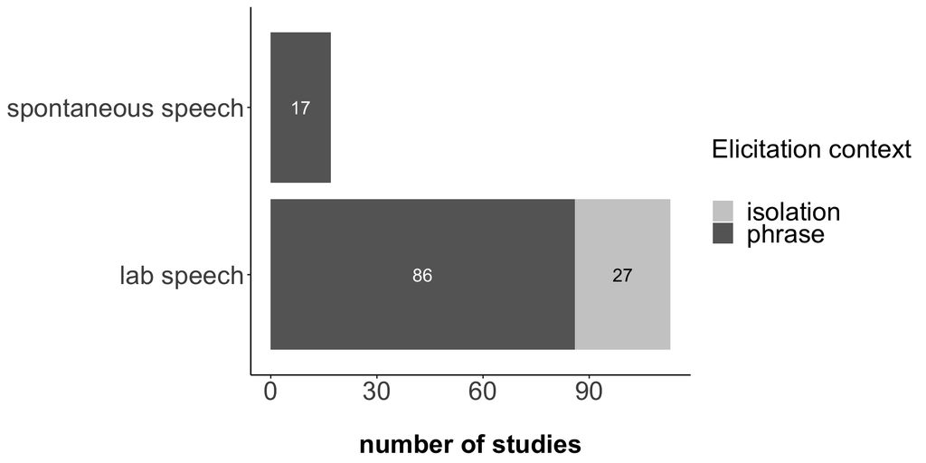

Number of studies as a function of corpus type (y-axis) and elicitation context in which target words appeared (color coded) for all (sub-) studies in the database. Note that studies using more than one type of context are included in the counts of all relevant categories. This plot corresponds to Figure 2 in Roettger and Gordon (2017: 3).

### Phrase position and accentuation patterns

Within laboratory speech, plot counts of elicitation methods according to the phrase position of the target word (varied, unspecified, non-final, final, controlled (both)) and the accompanying accentuation pattern (potentially confounded, controlled, unspecified).

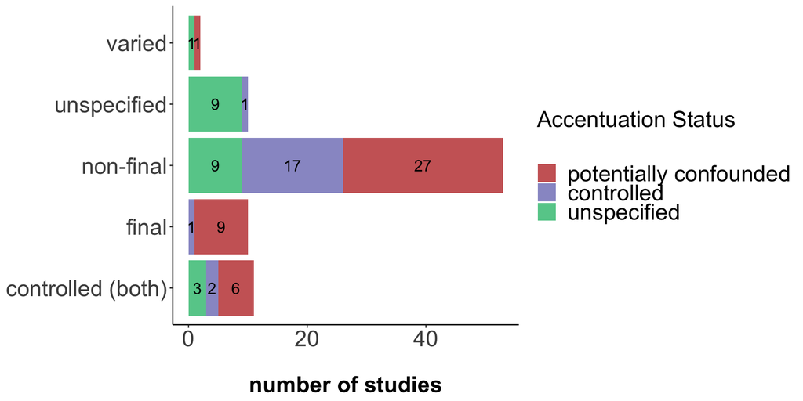

Number of studies as a function of target word position (y-axis) and accent information (color coded) within (sub-) studies using lab speech. Note that studies using more than one context are included in counts of all relevant categories. This plot corresponds to Figure 3 in Roettger & Gordon (2017: 5)

## Acoustic measurements

Plot counts of measured acoustic parameters alongside whether the respective authors reported them as being correlated or not.

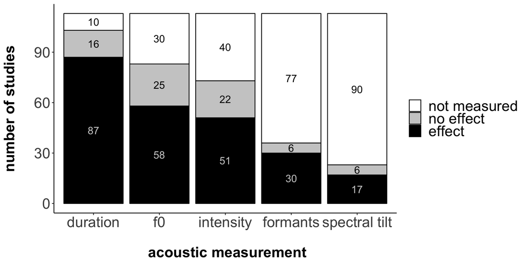

Number of (sub-) studies for which various acoustic correlates of stress were successful (black bars), unsuccessful (grey bars), and not measured (white bars) in differentiating stress level. This plot corresponds to Figure 2 in Gordon & Roettger (2017: 4).